# Lab 7 Assignment: Group 11

## GROUP 11:

#### Eleni-Sofia Tseperi s240066, Johanne Lund s233246, Marie Picquet s233736, Eglantine Anton s233242, Wu Qiuyan s241063

## Background

Breast cancer is one of the most prevalent forms of cancer, affecting millions of women worldwide. It occurs when cells in the breast begin to grow uncontrollably, forming a tumour that can be either benign (non-cancerous) or malignant (cancerous). Early detection is critical, as it significantly increases the chances of successful treatment and survival. However, diagnosing breast cancer accurately remains a challenge due to the variability in tumour characteristics.

## Aim

The aim is to use Principal Component Analysis (PCA) to reduce the dimensionality of the biopsy dataset, allowing us to visualize the data in new coordinates (principal components) that capture the most variation, helping to identify patterns and relationships in the breast cancer attributes.

## Load Libraries

```r
library(tidyverse, verbose = FALSE)
library(ggplot2, verbose = FALSE)
library(broom, verbose = FALSE)
library(cowplot, verbose = FALSE)
```

## Load Data

```r
biopsy <- read_csv("https://wilkelab.org/classes/SDS348/data_sets/biopsy.csv")
```

## Data Description

We’ll be analyzing the `biopsy` dataset, which comes originally from the MASS package. It is a breast cancer dataset from the University of Wisconsin Hospitals, Madison from Dr. William H. Wolberg. He assessed biopsies of breast tumors for 699 patients; each of nine attributes was scored on a scale of 1 to 10. The attributes are: clump_thickness, uniform_cell_size, uniform_cell_shape, marg_adhesion, epithelial_cell_size, bare_nuclei, bland_chromatin, normal_nucleoli, mitoses. The true outcome (benign/malignant) is also known.

Below is a quick overview of the dataset:

```r
biopsy |> sample_n(10)
```

```
# A tibble: 10 × 10
   clump_thickness uniform_cell_size uniform_cell_shape marg_adhesion
             <dbl>             <dbl>              <dbl>         <dbl>
 1               6                10                 10            10
 2               3                 2                  2             2
 3               3                 6                  6             6
 4               5                 6                  6             8
 5               3                 6                  4            10
 6               1                 1                  1             1
 7               6                 3                  2             1
 8               5                 3                  5             1
 9               1                 1                  1             1
10               5                 6                  5             6
# ℹ 6 more variables: epithelial_cell_size <dbl>, bare_nuclei <dbl>,
#   bland_chromatin <dbl>, normal_nucleoli <dbl>, mitoses <dbl>, outcome <chr>
```

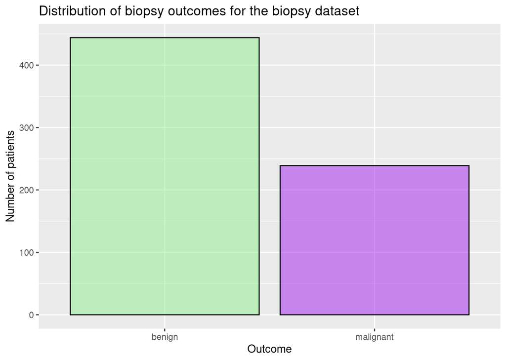

```r
biopsy |>
  count(outcome) |>
  ggplot(mapping = aes(x = outcome, y = n, fill=outcome)) +
  geom_col(position = "dodge", alpha=0.5, color="black") +
  labs(title = "Distribution of biopsy outcomes for the biopsy dataset",
       y = "Number of patients",
       x = "Outcome") +
  scale_fill_manual(values = c("malignant" = "purple", "benign" = "lightgreen")) +
  theme(legend.position = "none")
```

## Analysis

### Normalization and running the PCA:

```r
pca_data <- biopsy |>
  select(where(is.numeric)) |>
  scale() |>
  prcomp()
```

### Plotting the data in PC coordinates:

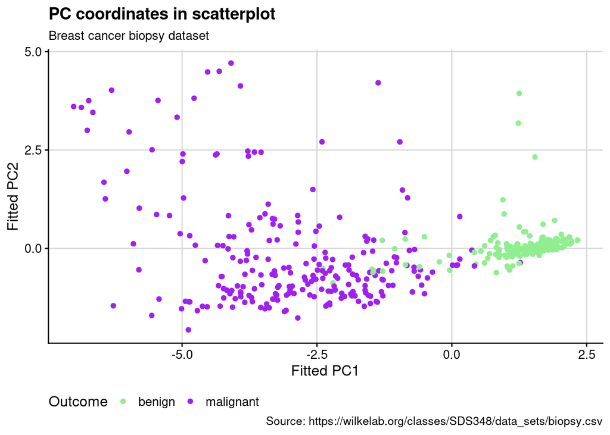

```r
pca_data |>
  augment(biopsy) |> # add original dataset back in
  ggplot(aes(.fittedPC1, .fittedPC2, color = outcome)) +
  geom_point(size = 1.5) +
  scale_color_manual(
    values = c(malignant = "purple", benign = "lightgreen")
  ) +
  theme_half_open(12) + background_grid() +
  labs(title="PC coordinates in scatterplot",
       subtitle = "Breast cancer biopsy dataset", x="Fitted PC1", y = "Fitted PC2", color="Outcome", caption="Source: https://wilkelab.org/classes/SDS348/data_sets/biopsy.csv") +
  theme(legend.position = "bottom")
```

### Plotting the rotation matrix

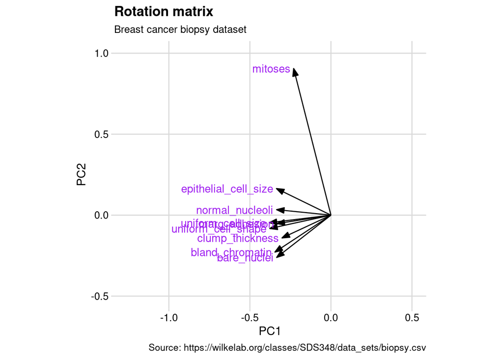

```r
arrow_style <- arrow(
  angle = 20, ends = "first", type = "closed", length = grid::unit(8, "pt")
)

pca_data |>
  tidy(matrix = "rotation") |>
  pivot_wider(names_from = "PC", names_prefix = "PC", values_from = "value") |>
  ggplot(aes(PC1, PC2)) +
  geom_segment(xend = 0, yend = 0, arrow = arrow_style) +
  geom_text(
    aes(label = column),
    hjust = 1, nudge_x = -0.02,
    color = "purple"
  ) +
  xlim(-1.25, .5) + ylim(-.5, 1) +
  coord_fixed() +
  theme_minimal_grid(12) +
  labs(title="Rotation matrix",
       subtitle = "Breast cancer biopsy dataset", x="PC1", y = "PC2", caption="Source: https://wilkelab.org/classes/SDS348/data_sets/biopsy.csv")
```

### Plotting the variance explained by each PC

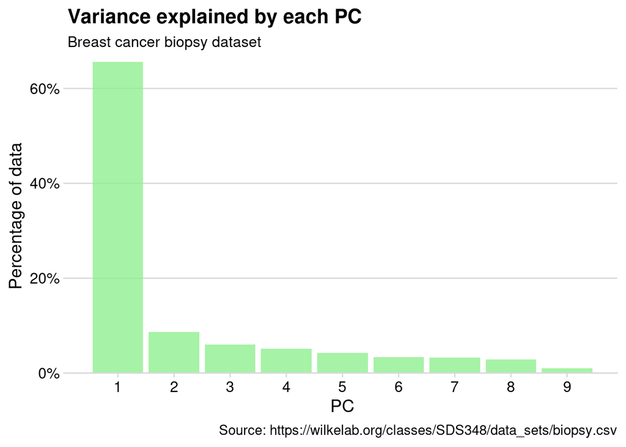

```r
pca_data |>
  tidy(matrix = "eigenvalues") |>
  ggplot(aes(PC, percent)) +
  geom_col(fill = "lightgreen", alpha = 0.8) +
  scale_x_continuous(breaks = 1:9) +
  scale_y_continuous(
    labels = scales::percent_format(),
    expand = expansion(mult = c(0, 0.01))
  ) +
  theme_minimal_hgrid() +
  labs(title="Variance explained by each PC",
       subtitle = "Breast cancer biopsy dataset", x="PC", y = "Percentage of data", caption="Source: https://wilkelab.org/classes/SDS348/data_sets/biopsy.csv")
```